# ECo 634 - Analysis of Environmental Data Lab

Lab 05: Modeling Errors

Michael France Nelson

Fall 2020

# Learning objectives, technical sills and concepts:

- Random number generation
- Distribution Functions
- Building custom functions
- Fitting deterministic models
- Calculating residuals
- Defining and quantifying error

# The Ricker Function

The Ricker funciton is a modification fo the exponential function. The formula is:

$f(x) = a \times x \times e^{-b \times x}$

You can see the general form of the curve (with some hints as to how to visually parameterize it) in McGarigal’s figure:

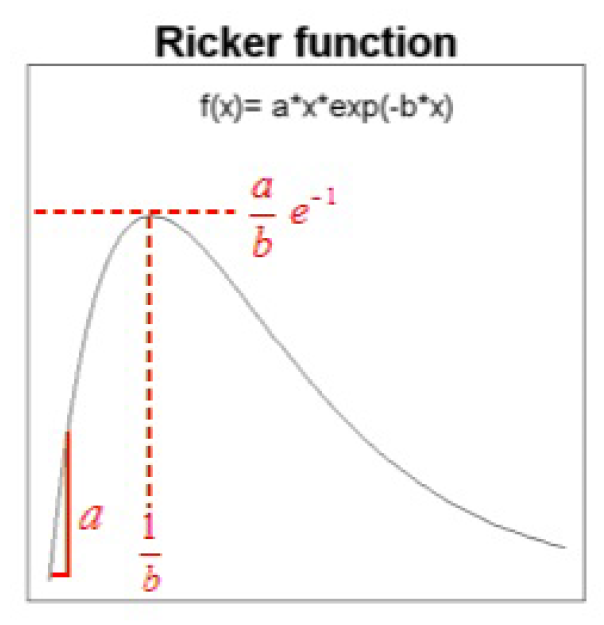

- Notice that the x-coordinate of the peak depends on the parameter `b`, the initial slope depends on the parameter `a`, while the height of the maximum depends on both parameters.

### We can create a Ricker function in R:

```r
ricker_fun = function(x, a, b)
{
  return(a * x * exp(-b * x))
}
```

Here’s a plot of the shape using the simplest possible parameters: a = 1 and b = 1:

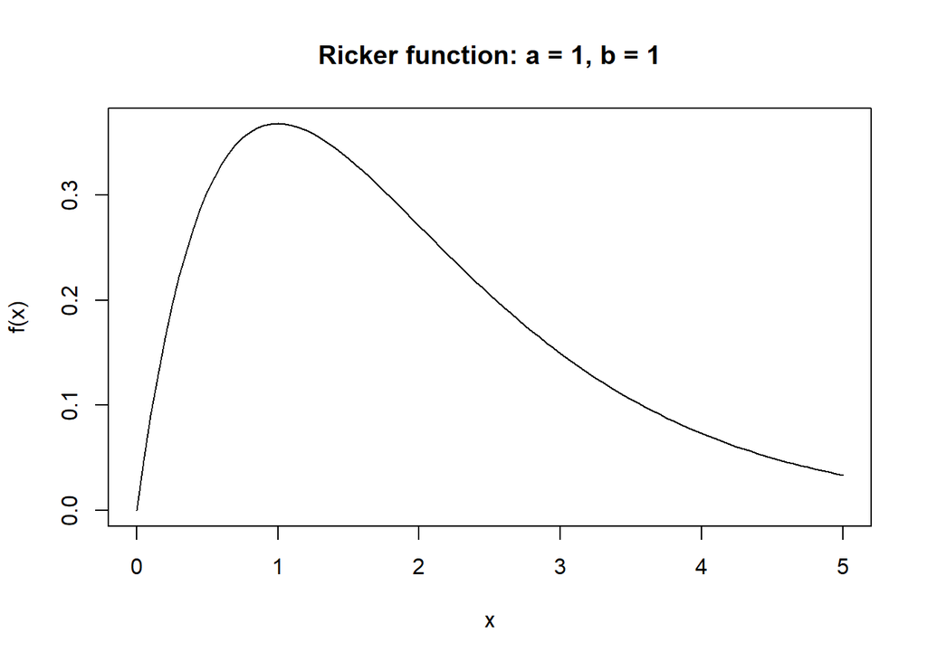

```r
curve(
  ricker_fun(x, 1, 1),
  from = 0, to = 5, add = FALSE,
  main = "Ricker function: a = 1, b = 1",
  ylab = "f(x)", xlab = "x")
```

- Note the use of the `curve()` function:
  - The `from` and `to` arguments tells `curve()` what range of x-values it should include in the plot.
  - The `add = FALSE` argument value creates a new plot.

# The exponential function

> The exponential function is the building block of the Ricker.

Here’s McGarigal’s infographic:

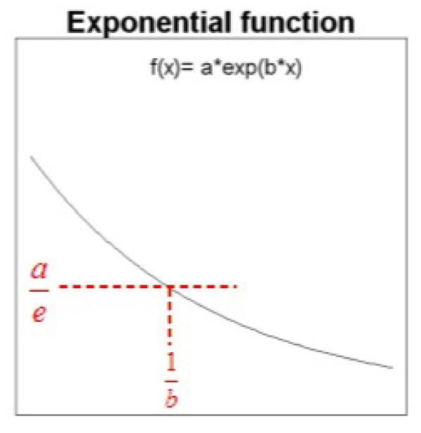

### We can create an exponential function in R:

I’ll let you build it! You can use the Ricker function code I wrote above as a template.

```r
exp_fun = function(x .......
```

NOTE: McGarigal defines the Ricker funciton with a negative sign before the parameter `b` but no negative sign before `b` in the exponential.

For consistency, you need to include the negative sign with parameter `b` in your exponential function definition.

### Plot of the exponential function

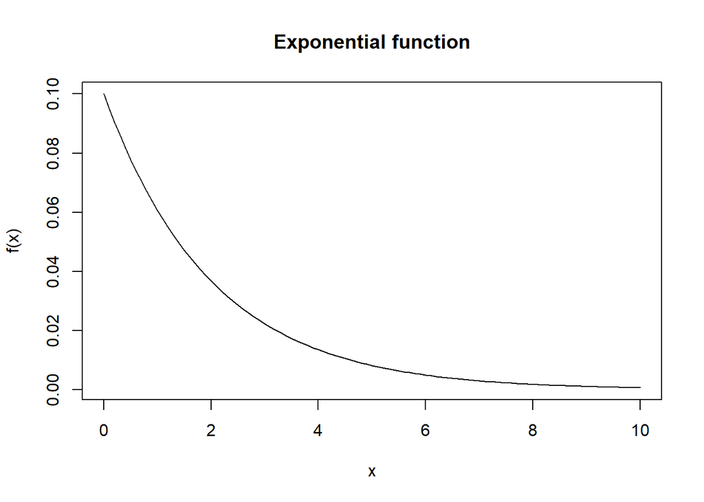

```r
curve(
  exp_fun(x, 0.1, 0.5),
  from = 0, to = 10, add = FALSE,
  main = "Exponential function",
  ylab = "f(x)", xlab = "x")
```

- What code could you use to create a similar plot?

# Simulating data with different stochastic distributions

We’ve used `curve()` to plot deterministic models using linear, logistic, Ricker, and exponential functions using parameter values we selected.

We can also create simulated data that use these functions a determinsitic model and r’s random deviates functions to generate the noise or ‘errors’.

## Simulated data on a line.

First, let’s choose 50 *uniformly-distributed* random x-values within the interval 2 to 10:

```r
# Seed the RNG so we can reproduce our results
set.seed(1234567)

# Specify the x-range and number of poitns:
n_pts = 50
x_min = 2
x_max = 10

# Generate the x-values
x_sim = runif(n_pts, min = x_min, max = x_max)
```

Next, we can choose an intercept and slope for our determinsitic model and generate the ‘predicted’ y values:

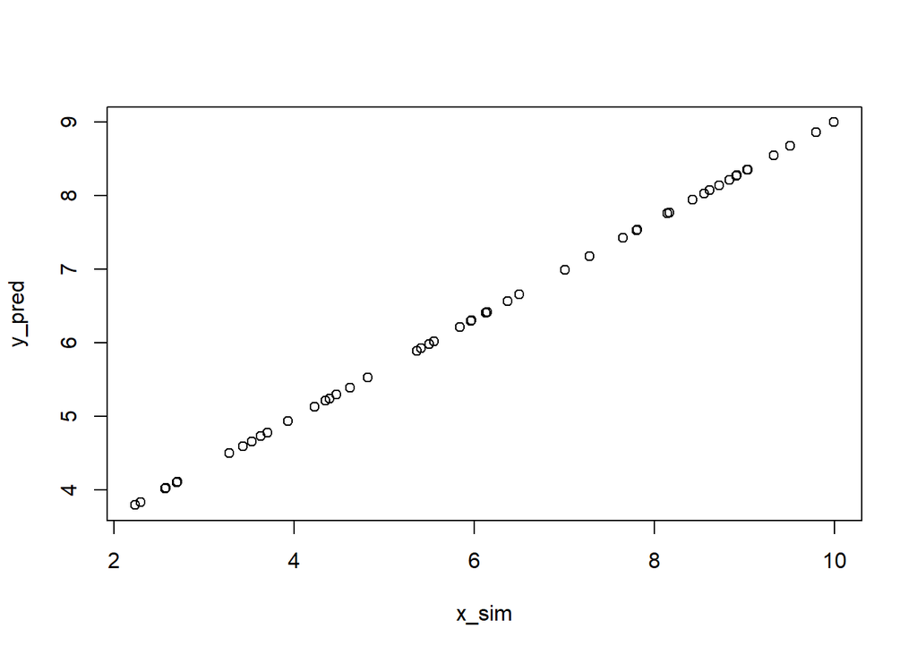

```r
param_intercept = 2.3
param_slope = 0.67
y_pred = param_intercept + x_sim * param_slope
plot(x_sim, y_pred)
```

## Normal errors 1

Now we can add some normally-distributed noise to generate our ‘observed’ y-values:

```r
error_mean = 0
error_sd = 0.25

y_observed =
  y_pred +
  rnorm(
    n = n_pts,
    mean = error_mean,
    sd = error_sd)
plot(x_sim, y_observed)
```

[output not shown]

## Normal errors 2

We could also use a more sophisticated stochastic model. For example, we could make the variablity larger with increasing values of x:

```r
error_mean = 0
error_sd = 0.1

y_observed_2 =
  y_pred +
  rnorm(
    n = n_pts,
    mean = error_mean,
    sd = error_sd * x_sim)
plot(x_sim, y_observed)
```

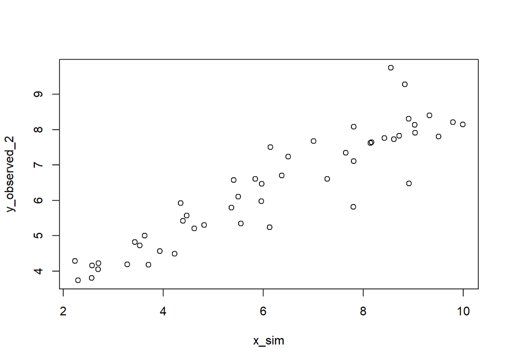

```r
plot(x_sim, y_observed_2)
```

- What did I do differently to make the points more variable as x increased?

## Exponentially-distributed errors.

To produce this plot, I generated exponentially-distributed errors using `rexp()`. I used a rate parameter of 1.2. I’ll let you think about how you might create such a plot yourselves.

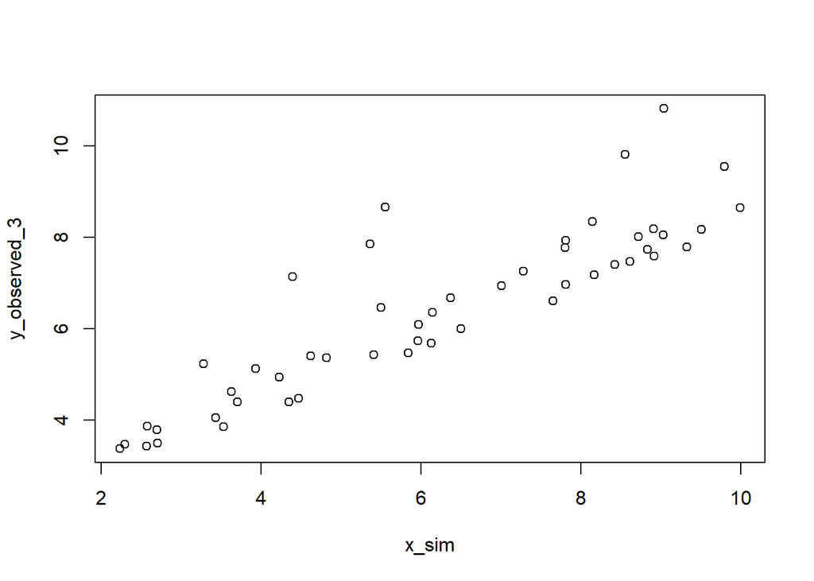

## Choosing a model

Consider the three plots

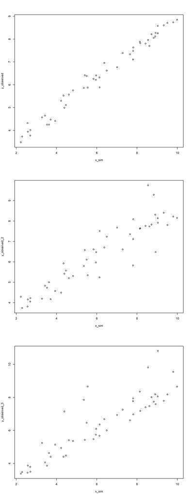

```r
par(mfrow = c(3, 1))
plot(x_sim, y_observed)
plot(x_sim, y_observed_2)
plot(x_sim, y_observed_3)
```

If you didn’t know the process that generated these data, how would you choose deterministic and stochastic models?

- The deterministic functions look linear, so we’ll focus ont he stochastic models.
- A first step is to examine histograms of the residuals:

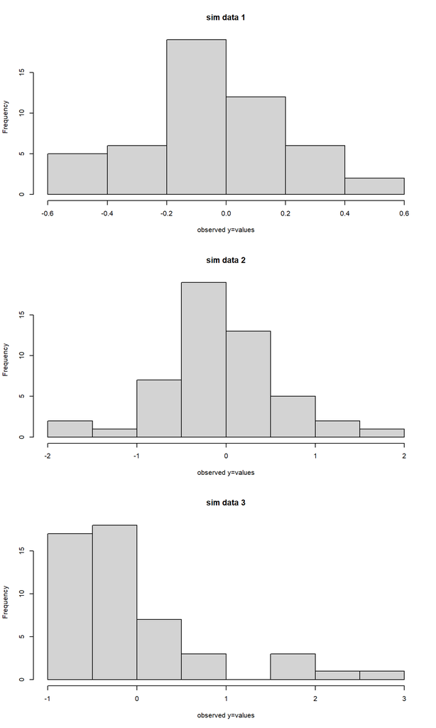

```r
par(mfrow = c(3, 1))
hist(y_observed - y_pred, main = "sim data 1", xlab = "observed y=values")
hist(y_observed_2 - y_pred, main = "sim data 2", xlab = "observed y=values")
hist(y_observed_3 - y_pred, main = "sim data 3", xlab = "observed y=values")
```

We’ll apply these concepts to a real data set below.

# Marbled salamander dispersal data

## Background

The data for this exercise represent the dispersal of juvenile marbled salamanders from their natal ponds to neighboring ponds.

The data were derived from a long-term study of marbled salamanders in western Massachusetts in which a cluster of 14 vernal pools were monitored continuously between 1999-2004. All juveniles were marked upon leaving their natal ponds. Subsequent recaptures at non-natal ponds were used to determine dispersal rates between ponds for first-time breeders (ftb).

In the data set provided, the dispersal rates have been standardized to account for several factors, including the propensity for dispersal from each pond and the available distances between ponds owing to the unique configuration of ponds. The data set includes three variables:

1. `dist.class` = distance class, based on 100 m intervals;
2. `disp.rate.ftb` = standardized dispersal rate for first-time breeders, which can be interpreted as a relative dispersal probability.
3. `disp.rate.eb` = standardized dispersal rate for experienced breeders, which can be interpreted as arelative dispersal probability.

Obtain the data file here:

https://michaelfrancenelson.github.io/eco_602_634_2020/data/salamander_dispersal.csv

You’ll try fitting three deterministic functions to the data:

1. linear
2. exponential
3. Ricker

# Instructions

Your assignment is to examine the data set provided (dispersal.csv) and find at least three alternative mathematical functions to describe the apparent relationship between juvenile dispersal and distance. The overall goals are for you to

1. Examine the data set. Plot the relationship between juvenile dispersal (disp.rate.ftb) and distance (dist.class).
2. Visually parameterize linear, exponential, and Ricker functions via trial-and-error to fit the data.
- Note: Be patient, we’ll eventually use R’s power to automatically fit model parameters. For now, the goal is graphical intuition.
3. Calculate the residuals and propose a distribution to model the errors.

# Lab Questions

## Question 01: Exponential plots

Instructions:

1. Complete the template R code to build your exponential function. Make sure you read the note about parameter `b` in the lab instructions.
2. To gain visual intuition, try using `curve()` to plot your function.
- Try out different values of the two parameters as well as plotting over different ranges of x-values.
- Try plotting two or more curves with slightly different parameter values on the same plot
- You may need to try out different ranges of x-values in your plot windows to make sure you are focusing on the interesting parts of the curves.
- Try different line colors, widths, and textures.

An example exploratory plotting exercise:

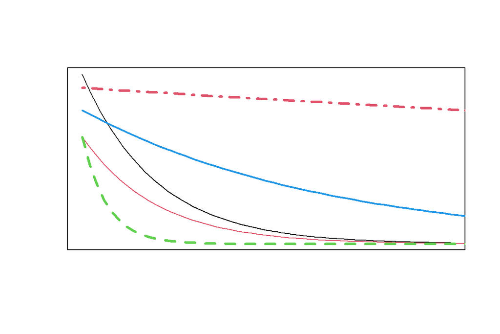

### Questions

- Q1 (2 pts.) Paste the R code you used to create `exp_fun()`
- Q2 (3 pts.) Create a single plot containing 4 curves with these parameter values:
  - curve 1: a = 1.9, b = 0.1, line color = black, line texture = solid
  - curve 2: a = 1.9, b = 0.3, line color = black, line texture = dotted
  - curve 3: a = 1.2, b = 0.2, line color = red, line texture = solid
  - curve 4: a = 1.2, b = 0.4, line color = red, line texture = dotted

### Solution

### Meta-information

extitle: Exponential plots

extype: string

exsolution: nil

exname: lab 5

exsection: lab 5

exextra[essay,logical]: TRUE

exextra[essay_format,character]: editor

exextra[essay_required,logical]: TRUE

exextra[essay_fieldlines,numeric]: 10

exextra[essay_attachments,numeric]: 1

exextra[essay_attachmentsrequired,logical]: TRUE

expoints: 5

## Question 02: Exponential parameters

> Consider the plot you made with the 4 exponential curves.

Observe how the curves vary as you change the two parameters’ values.

### Questions

- Q1 (2 pts.) Qualitatively describe what happens to the curve as you vary parameter `a`
- Q2 (2 pts.) Qualitatively describe what happens to the curve as you vary parameter `b`

### Solution

- Parameter `a` sets the y-intercept.
- Parameter `b` sets the [initial] steepness of the decay.
- Students may notice that a also affects the steepness of the decay.

### Meta-information

extitle: Exponential parameters

extype: string

exsolution: nil

exname: lab 5

exsection: lab 5

exextra[essay,logical]: TRUE

exextra[essay_format,character]: editor

exextra[essay_required,logical]: TRUE

exextra[essay_fieldlines,numeric]: 15

expoints: 4

## Question 03: Ricker plots

Instructions:

1. To gain visual intuition, try using `curve()` to plot the Ricker function.
- Try out different values of the two parameters as well as plotting over different ranges of x-values.
- Try plotting two or more curves with slightly different parameter values on the same plot
- You may need to try out different ranges of x-values in your plot windows to make sure you are focusing on the interesting parts of the curves.
- Try different line colors, widths, and textures.

An example exploratory plotting exercise:

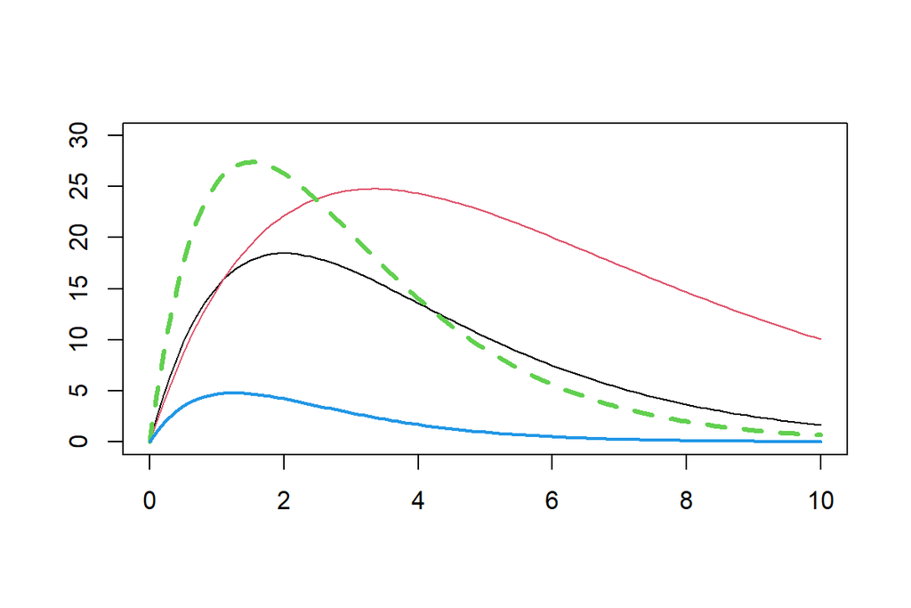

### Questions

- Q1 (4 pts.) Create a single plot containing 6 Ricker curves with these parameter values:
  - curve 1: a = 25, b = 0.1, line color = black, line texture = solid
  - curve 2: a = 20, b = 0.2, line color = black, line texture = dotted
  - curve 3: a = 10, b = 0.2, line color = black, line texture = dotted
  - curve 4: a = 75, b = 0.3, line color = red, line texture = solid
  - curve 5: a = 50, b = 0.3, line color = red, line texture = dotted
  - curve 6: a = 40, b = 0.3, line color = red, line texture = dotted

### Solution

### Meta-information

extitle: Ricker plots

extype: string

exsolution: nil

exname: lab 5

exsection: lab 5

exextra[essay,logical]: TRUE

exextra[essay_format,character]: noinline

exextra[essay_required,logical]: FALSE

exextra[essay_fieldlines,numeric]: 5

exextra[essay_attachments,numeric]: 1

exextra[essay_attachmentsrequired,logical]: TRUE

expoints: 4

## Question 04: Ricker params

Instructions:

1. To gain visual intuition, try using `curve()` to plot the Ricker function.
- Try out different values of the two parameters as well as plotting over different ranges of x-values.
- Try plotting two or more curves with slightly different parameter values on the same plot
- You may need to try out different ranges of x-values in your plot windows to make sure you are focusing on the interesting parts of the curves.
- Try different line colors, widths, and textures.

### Questions

- Q1 (2 pts.) Qualitatively describe how the `a` parameter influences the curve shape.
- Q2 (2 pts.) Qualitatively describe how the `b` parameter influences the curve shape.

NOTE: make sure you choose an appropriate range of x-values in your plot.

### Solution

### Meta-information

extitle: Ricker params

extype: string

exsolution: nil

exname: lab 5

exsection: lab 5

exextra[essay,logical]: TRUE

exextra[essay_format,character]: noinline

exextra[essay_required,logical]: FALSE

exextra[essay_fieldlines,numeric]: 5

exextra[essay_attachments,numeric]: 1

exextra[essay_attachmentsrequired,logical]: TRUE

expoints: 4

## Question 05: salamander data scatterplot

Instructions:

1. Read the salamander dispersal data into a `data.frame` called `dat_dispersal`.
2. Create a scatterplot of distance class and dispersal rate of first time breeding salamanders.

### Questions

- Q1 (1 pts.) Upload an image file with your scatterplot. Make sure it has appropriate axis labels and title.
- Q2 (2 pts.) Describe, in nontechnical language, what is shown on the x-axis
- Q3 (2 pts.) Describe, in nontechnical language, what is shown on the y-axis

### Solution

### Meta-information

extitle: salamander data scatterplot

extype: string

exsolution: nil

exname: lab 4

exsection: lab 4

exextra[essay,logical]: TRUE

exextra[essay_format,character]: editor

exextra[essay_required,logical]: TRUE

exextra[essay_fieldlines,numeric]: 5

exextra[essay_attachments,numeric]: 1

exextra[essay_attachmentsrequired,logical]: TRUE

expoints: 5

## Question 06: salamander linear model

Instructions:

### Questions

- Q1 (2 pts.) Upload an image file with your scatterplot and fitted line. Make sure it has appropriate axis labels and title.

### Meta-information

extitle: salamander linear model

extype: string

exsolution: nil

exname: lab 4

exsection: lab 4

exextra[essay,logical]: TRUE

exextra[essay_format,character]: noinline

exextra[essay_required,logical]: TRUE

exextra[essay_fieldlines,numeric]: 5

exextra[essay_attachments,numeric]: 1

exextra[essay_attachmentsrequired,logical]: TRUE

expoints: 2

## Question 07: salamander exponential model

Instructions:

1. Using the scatterplot of the dispersal data, visually fit an model

### Questions

- Q1 (4 pts.) Upload an image file with your scatterplot and fitted curve. Make sure it has appropriate axis labels and title.

### Solution

### Meta-information

extitle: salamander linear model

extype: string

exsolution: nil

exname: lab 4

exsection: lab 4

exextra[essay,logical]: TRUE

exextra[essay_format,character]: noinline

exextra[essay_required,logical]: TRUE

exextra[essay_fieldlines,numeric]: 5

exextra[essay_attachments,numeric]: 1

exextra[essay_attachmentsrequired,logical]: TRUE

expoints: 4

## Question 08: salamander ricker model

Instructions:

1. Using the scatterplot of the dispersal data, visually fit a ricker curve model.

### Questions

- Q1 (4 pts.) Upload an image file with your scatterplot and fitted curve. Make sure it has appropriate axis labels and title.

### Meta-information

extitle: salamander ricker model

extype: string

exsolution: nil

exname: lab 4

exsection: lab 4

exextra[essay,logical]: TRUE

exextra[essay_format,character]: noinline

exextra[essay_required,logical]: TRUE

exextra[essay_fieldlines,numeric]: 5

exextra[essay_attachments,numeric]: 1

exextra[essay_attachmentsrequired,logical]: TRUE

expoints: 4

## Question 09: salamander linear model residuals

Instructions:

1. Using the parameters you chose for your linear fit, calculate the residuals and store them in a vector `resids_linear`.

### Questions

- Q1 (3 pts.) Paste the code you used to create `resids_linear`.
- Q1 (1 pts.) Upload an image file with a histogram of the residuals of your linear model.

### Meta-information

extitle: salamander linear model

extype: string

exsolution: nil

exname: lab 4

exsection: lab 4

exextra[essay,logical]: TRUE

exextra[essay_format,character]: noinline

exextra[essay_required,logical]: TRUE

exextra[essay_fieldlines,numeric]: 5

exextra[essay_attachments,numeric]: 1

exextra[essay_attachmentsrequired,logical]: TRUE

expoints: 4

## Question 10: salamander exponential model residuals

Instructions:

1. Using the parameters you chose for your exponential fit, calculate the residuals and store them in a vector `resids_exp`.

### Questions

- Q1 (4 pts.) Upload an image file with a histogram of the residuals of your exponential model.

### Solution

### Meta-information

extitle: salamander linear model

extype: string

exsolution: nil

exname: lab 4

exsection: lab 4

exextra[essay,logical]: TRUE

exextra[essay_format,character]: noinline

exextra[essay_required,logical]: TRUE

exextra[essay_fieldlines,numeric]: 5

exextra[essay_attachments,numeric]: 1

exextra[essay_attachmentsrequired,logical]: TRUE

expoints: 4

## Question 11: salamander ricker model residuals

Instructions:

1. Using the parameters you chose for your Ricker curve fit, calculate the residuals and store them in a vector `resids_ricker`.
2. Using the scatterplot of the dispersal data, visually fit a ricker curve model.

### Questions

- Q1 (4 pts.) Upload an image file with a histogram of the residuals of your Ricker curve model.

### Meta-information

extitle: salamander ricker model

extype: string

exsolution: nil

exname: lab 4

exsection: lab 4

exextra[essay,logical]: TRUE

exextra[essay_format,character]: noinline

exextra[essay_required,logical]: TRUE

exextra[essay_fieldlines,numeric]: 5

exextra[essay_attachments,numeric]: 1

exextra[essay_attachmentsrequired,logical]: TRUE

expoints: 4